# Han_02

Wanting Han

September 21, 2016

#### 1a. Say “Vole vasopressin” 10 times as fast as you can. How many times did you trip up?

- Once.

#### 1b. What is the mean, median, sd, and interquartile range of the sample?

```r
vole_mean
```

```
## [1] 58.05
```

```r
vole_median
```

```
## [1] 59.5
```

```r
vole_sd
```

```
## [1] 29.75244
```

```r
vole_IQR
```

```
## [1] 44.25
```

#### 1c. What is the standard error of the mean (do this with a formula!)?

```r
vole_n <- vole_vaso %>% length %>% sqrt
vole_se <- vole_sd/vole_n
vole_se
```

```
## [1] 6.652849
```

#### 1d. What does the standard error of the mean tell you about our estimate of the mean values of the population of vole vassopressin?

#### 2a. Use sample() to get just one resample with a sample size of 10. What is its upper quartile?

```r
vole_s10 <-
  sample(vole_vaso, size = 10, replace = TRUE)
quantile(vole_s10, probs = 0.75)
```

```
## 75%
##  82
```

### 2b. Build an initial data frame for simulations with the sample sizes 5 through 20. Have 100 simulations per sample size.

```r
samp_size <-
  rep(5:20, times = 100)
vole_sample_df <-
  data.frame("samp_size" = samp_size)
vole_sample_df$sim <-
  1:nrow(vole_sample_df)
```

#### 2c. Use this data frame to get simulated upper quartiles for each sample size.

```r
vole_sample_df_Q <-
  vole_sample_df %>%
  group_by(sim) %>%
  mutate(quantile_sim = quantile(sample(vole_vaso, samp_size, replace = TRUE), probs = 0.75)) %>% ungroup()
vole_sample_df_Q
```

```
## # A tibble: 1,600 × 3
##    samp_size   sim quantile_sim
##        <int> <int>        <dbl>
## 1          5     1        86.00
## 2          6     2        92.50
## 3          7     3        95.00
## 4          8     4        86.50
## 5          9     5        86.00
## 6         10     6        83.75
## 7         11     7        91.00
## 8         12     8        50.00
## 9         13     9        82.00
## 10        14    10        76.25
## # ... with 1,590 more rows
```

### 2d. With a plot, make a guesstimate as to the best sample size for estimating the upper quartile of the population.

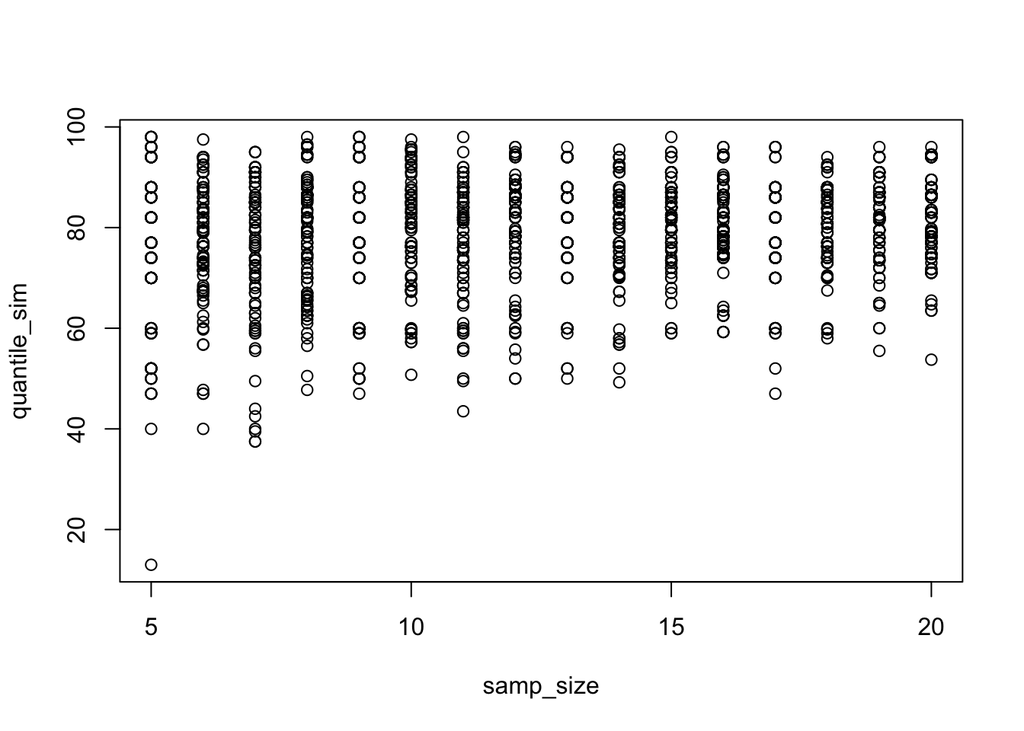

```r
plot(quantile_sim ~ samp_size, data = vole_sample_df_Q)
```

### 3a. With the upper quartile simulations, calculate the SD for each sample size using dplyr

```r
vole_sample_df_SD <- vole_sample_df_Q %>% group_by(samp_size) %>% mutate(SD = sd(quantile_sim)) %>% ungroup()
vole_sample_df_SD
```

```
## # A tibble: 1,600 × 4
##    samp_size   sim quantile_sim        SD
##        <int> <int>        <dbl>     <dbl>
## 1          5     1        86.00 16.434492
## 2          6     2        92.50 11.527585
## 3          7     3        95.00 14.049784
## 4          8     4        86.50 11.372952
## 5          9     5        86.00 13.383161
## 6         10     6        83.75 11.076284
## 7         11     7        91.00 11.038357
## 8         12     8        50.00 10.500280
## 9         13     9        82.00  9.829717
## 10        14    10        76.25  9.709512
## # ... with 1,590 more rows
```

#### 3c. What is the CI of the upper quartile with a sample size of 10. What does this mean?

#### 3d. Extra Credit: Instead of having each sim calculate a upper quartile, and then sifting down to the SE of that upper quartile (or the CI), have each simulation calculate a CI. Then, for just a sample size of 10, how many CI’s contain the true value of 83?